# Week 5 - Data Understanding and Preparation (Part 3)

## Notes

```r
# Clear the workspace
rm(list=ls())

# Load the relevant packages
library('gapminder')
library('tidyverse')
library('gridExtra')

# This is from the actual Google sheets
gapminderall <- read_csv('data/Case Study 1 - Gapminder/gapminderall.csv', col_types=cols())

# This is from the R library
data(gapminder)
```

### Checking Validity

One way we can check the validity of data is to check between two sources. In the case of the gapminder data, we can use:

- `setdiff()` which lists the actual differences based on the object called first.
- `setequal()` which returns TRUE if the two objects are equal.

```r
setdiff(unique(gapminder$country), unique(gapminderall$country))
```

1. 'Afghanistan'

2. 'Korea, Dem. Rep.'

3. 'Myanmar'

4. 'Reunion'

5. 'Sao Tome and Principe'

6. 'Somalia'

7. 'Taiwan'

### Duplicates

We can remove duplicates easily with the `distinct()` function. In the gapminder data set, all rows are distinct.

```r
print(dim(gapminderall))
print(dim(distinct(gapminderall)))
```

```
[1] 10545     9
[1] 10545     9
```

### Missing Values

It is important to consider the underlying reasons for why there is missing data. Missing data can create major risk of producing incorrect conclusions due to absence of relevant information leading to invalid results.

Missing data are typically grouped into three categories. This [website](https://www-users.york.ac.uk/~mb55/intro/typemiss4.htm) provides an awesome explanation. This [too](https://stefvanbuuren.name/fimd/sec-MCAR.html).

- **Missing completely at random** (MCAR)
  - The missing data is independent of the observed and unobserved data and occur *entirely at random*.
  - That is, the missingness has nothing to do with the person being studied.
  - In other words, the data which remains can be considered a simple random sample of the full data set.
  - For example, a questionnaire might get lost.
  - This is generally regarded as a strong and often unrealistic assumption.
- **Missing at random** (MAR)
  - The missing data is systematically related to the observed but not the unobserved data.
  - That is, the missingness has to do with the person, but can be predicted from other information about the person.
  - This is easiest explained with an example. Consider that a survey is being conducted on depression. Male participants are less likely to complete the survey than female participants. So, the cause of the missing data is due to gender (observed) rather than their level of depression (unobserved).
  - MAR is more general and more realistic than MCAR. Hence modern missing data methods generally start from the MAR assumption.
- **Missing not at random** (MNAR)
  - The missing data is systematically related to the unobserved data.
  - If neither MCAR or MAR hold, then we consider MNAR.
  - Continuing on from the previous example of a survey being conducted on depression. The missing data is considered MNAR if participants fail to complete the survey because of their level of depression (unobserved).

And to handle missing values we can:

- **Do nothing** - While some R functions will automatically omit NAs, others will fail and produce an error.
- **Omit all observations with NAs** - In large datasets, this could be a consideration, but there's also the risk of losing information.
- **Impute values** - This could include:
  - Substituting NAs with 0.
  - Substituting with the mean, median or mode value.
  - Creating a custom algorithm to impute the values.

#### Summarising Missing Values

Before we can handle missing values, we must understand and explore where the missing values occur. We can do this with the `naniar` package which provides many ways to summarise missing data or `sapply()` in base R.

```r
library('naniar')
miss_var_summary(gapminderall)
```

| variable | n_miss | pct_miss |
| --- | --- | --- |
| gdp | 2755 | 26.126126 |
| infant_mortality | 1453 | 13.779042 |
| fertility | 187 | 1.773352 |
| population | 185 | 1.754386 |
| country | 0 | 0.000000 |
| year | 0 | 0.000000 |
| life_expectancy | 0 | 0.000000 |
| continent | 0 | 0.000000 |
| region | 0 | 0.000000 |

```r
sapply(gapminderall, function(x){(sum(is.na(x)))})
```

**country**

0

**year**

0

**infant_mortality**

1453

**life_expectancy**

0

**fertility**

187

**population**

185

**gdp**

2755

**continent**

0

**region**

0

#### Imputing

Once we have an idea of the missing data, we can impute using either:

- The `dplyr` package and `ifelse()`.
- The `naniar` and `simputation` packages.

Using `dplyr` and `ifelse()`, we change the missing values to 0 in the first example, and the mean value in the second example. Note that `na.rm=TRUE` ignores NAs in the calculation of the mean.

```r
gapminder_zero <- gapminderall %>%
    mutate(
        infant_mortality=ifelse(is.na(infant_mortality), 0, infant_mortality),
        fertility=ifelse(is.na(fertility), 0, fertility),
        population=ifelse(is.na(population), 0, population),
        gdp=ifelse(is.na(gdp), 0, gdp),
    )
head(gapminder_zero, 3)
# miss_var_summary(gapminder_zero)
```

| country | year | infant_mortality | life_expectancy | fertility | population | gdp | continent | region |
| --- | --- | --- | --- | --- | --- | --- | --- | --- |
| Albania | 1960 | 115.4 | 62.87 | 6.19 | 1636054 | 0 | Europe | Southern Europe |
| Algeria | 1960 | 148.2 | 47.50 | 7.65 | 11124892 | 13828152297 | Africa | Northern Africa |
| Angola | 1960 | 208.0 | 35.98 | 7.32 | 5270844 | 0 | Africa | Middle Africa |

```r
gapminder_mean <- gapminderall %>%
    mutate(
        infant_mortality=ifelse(is.na(infant_mortality), mean(infant_mortality, na.rm=TRUE), infant_mortality),
        fertility=ifelse(is.na(fertility), mean(fertility, na.rm=TRUE), fertility),
        population=ifelse(is.na(population), mean(population, na.rm=TRUE), population),
        gdp=ifelse(is.na(gdp), mean(gdp, na.rm=TRUE), gdp),
    )
head(gapminder_mean, 3)
# miss_var_summary(gapminder_mean)
```

| country | year | infant_mortality | life_expectancy | fertility | population | gdp | continent | region |
| --- | --- | --- | --- | --- | --- | --- | --- | --- |
| Albania | 1960 | 115.4 | 62.87 | 6.19 | 1636054 | 155913472931 | Europe | Southern Europe |
| Algeria | 1960 | 148.2 | 47.50 | 7.65 | 11124892 | 13828152297 | Africa | Northern Africa |
| Angola | 1960 | 208.0 | 35.98 | 7.32 | 5270844 | 155913472931 | Africa | Middle Africa |

Using `naniar` and `simputation`,

```r
library('naniar')
library('simputation')
```

**Replacing all NAs with zeros**

Let's go through each function of code below:

- `bind_shadow(only_miss=TRUE)` creates a column called 'col_NA' only for columns with missing values.
- `add_label_shadow()` creates a column called 'any_missing' which is pretty self-explanatory.
- `impute_const(col~0)` imputes zeros into that column.

```r
gap_zero <- gapminderall %>%
    bind_shadow(only_miss=TRUE) %>%
    add_label_shadow() %>%
    impute_const(fertility~0) %>%
    impute_const(population~0) %>%
    impute_const(infant_mortality~0) %>%
    impute_const(gdp~0)
head(gap_zero, 3)
# miss_var_summary(gap_zero)
```

| country | year | infant_mortality | life_expectancy | fertility | population | gdp | continent | region | infant_mortality_NA | fertility_NA | population_NA | gdp_NA | any_missing |
| --- | --- | --- | --- | --- | --- | --- | --- | --- | --- | --- | --- | --- | --- |
| Albania | 1960 | 115.4 | 62.87 | 6.19 | 1636054 | 0 | Europe | Southern Europe | !NA | !NA | !NA | NA | Missing |
| Algeria | 1960 | 148.2 | 47.50 | 7.65 | 11124892 | 13828152297 | Africa | Northern Africa | !NA | !NA | !NA | !NA | Not Missing |
| Angola | 1960 | 208.0 | 35.98 | 7.32 | 5270844 | 0 | Africa | Middle Africa | !NA | !NA | !NA | NA | Missing |

**Replacing all NAs with mean**

```r
gap_mean <- gapminderall %>%
    impute_mean_all()
head(gap_mean, 3)
# miss_var_summary(gap_mean)
```

| country | year | infant_mortality | life_expectancy | fertility | population | gdp | continent | region |
| --- | --- | --- | --- | --- | --- | --- | --- | --- |
| Albania | 1960 | 115.4 | 62.87 | 6.19 | 1636054 | 155913472931 | Europe | Southern Europe |
| Algeria | 1960 | 148.2 | 47.50 | 7.65 | 11124892 | 13828152297 | Africa | Northern Africa |
| Angola | 1960 | 208.0 | 35.98 | 7.32 | 5270844 | 155913472931 | Africa | Middle Africa |

#### Replacing all NAs with median

```r
gap_median <- gapminderall %>%
    impute_median_all()
head(gap_median, 3)
```

| country | year | infant_mortality | life_expectancy | fertility | population | gdp | continent | region |
| --- | --- | --- | --- | --- | --- | --- | --- | --- |
| Albania | 1960 | 115.4 | 62.87 | 6.19 | 1636054 | 9498095348 | Europe | Southern Europe |
| Algeria | 1960 | 148.2 | 47.50 | 7.65 | 11124892 | 13828152297 | Africa | Northern Africa |
| Angola | 1960 | 208.0 | 35.98 | 7.32 | 5270844 | 9498095348 | Africa | Middle Africa |

#### Replacing all NAs with linear imputation

We do this with the `simputation` package.

```r
gap_lm <- gapminderall %>%
    bind_shadow(only_miss=TRUE) %>%
    add_label_shadow() %>%
    impute_lm(fertility ~ life_expectancy) %>%
    impute_lm(population ~ life_expectancy + fertility + year) %>%
    impute_lm(infant_mortality ~ life_expectancy + fertility) %>%
    impute_lm(gdp ~ life_expectancy + year)
head(gap_lm, 3)
```

| country | year | infant_mortality | life_expectancy | fertility | population | gdp | continent | region | infant_mortality_NA | fertility_NA | population_NA | gdp_NA | any_missing |
| --- | --- | --- | --- | --- | --- | --- | --- | --- | --- | --- | --- | --- | --- |
| Albania | 1960 | 115.4 | 62.87 | 6.19 | 1636054 | 163717886350 | Europe | Southern Europe | !NA | !NA | !NA | NA | Missing |
| Algeria | 1960 | 148.2 | 47.50 | 7.65 | 11124892 | 13828152297 | Africa | Northern Africa | !NA | !NA | !NA | !NA | Not Missing |
| Angola | 1960 | 208.0 | 35.98 | 7.32 | 5270844 | -218486732820 | Africa | Middle Africa | !NA | !NA | !NA | NA | Missing |

### Outliers

The options to deal with outliers is similar to that of missing values:

- **Keep the outlier**
- **Drop the outlier** - Using `filter()`
- **Cap the outlier** - Using `mutate()` and `ifelse()`; or `pmin()` or `pmax()`
- **Impute the outlier** - Using `mutate()` and `ifelse()` to impute the mean / median

### Correlation Considerations

> "Correlation does not imply causation" - Dr. Herbert West

These include:

- **Spurious correlation** - This is when two variables are statistically related but not directly causally related. We have to be careful not to over-interpret associations between variables.
- **Outliers** - Correlations can sometimes be driven by a few outliers. It is important to identify outliers when exploring the data.
- **Confounders** - Confounding occurs when an extraneous $x$ variable that is not of direct interest to the study has an influence on the response $y$ and must therefore be taken into account or controlled for. If not, incorrect results may be obtained.
  - Note that, as you include more variables, you lessen the bias but run the risk of introducing confounding variables. This will cause collinearity which increases the variance and reduces the precision of the estimates.
  - There is no formal statistical test to determine if confounding has occurred. We need to use judgement in conjunction with graphical evidence to make an informed decision.
  - For a small number of confounders, we could use stratification which is a method of sampling from a population which can be partitioned into subpopulations.
  - For large number of confounders, regression modelling allows the analysis to control for them.
- **Simpson's Paradox** - This is when the sign of the correlation flips when comparing the entire population and specific subsets of the population. It is most easily explained with an example, see the visual below. For the entire population (males and females), the correlation is positive. However, once we subset the population by gender, the correlations within each subset is negative.

[figure not shown]

#### Outliers

Looking at outliers a bit more closesly, let's create a hundred values each from $N(100,1)$ and $N(80,1)$, and standardise all values except the 10th value such that they now come from the $N(0,1)$ distribution. We plot the two vectors to see for easier reference

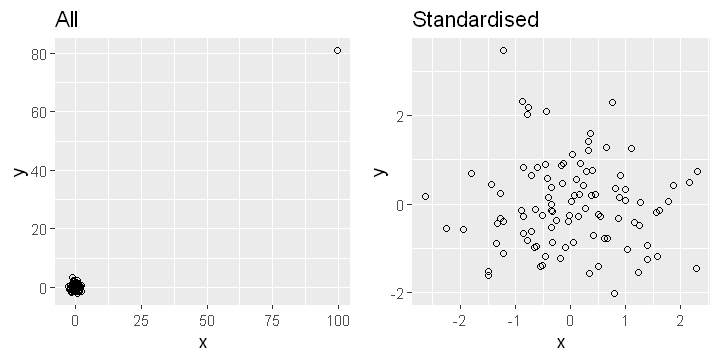

```r
set.seed(123)
x <- rnorm(100, 100, 1) # 100 values from X ~ N(100, 1)
y <- rnorm(100, 80, 1) # 100 values from Y ~ N(80, 1)

# Standardising every value except the 10th value
x[-10] <- scale(x)[-10]
y[-10] <- scale(y)[-10]
temp <- data.frame(cbind(x, y))

options(repr.plot.width = 6, repr.plot.height = 3)
all <- temp %>%
    ggplot(aes(x, y)) +
    geom_point(shape=21) +
    ggtitle('All')
standardised <- temp[-10,] %>%
    ggplot(aes(x, y)) +
    geom_point(shape=21) +
    ggtitle('Standardised')
grid.arrange(all, standardised, ncol=2)
```

```r
print(round(cor(x, y),2))
print(round(cor(x[-10], y[-10]),2))
```

```
[1] 0.99
[1] -0.04
```

Now, let's take a look at the two sets of correlations above:

- If we include all values, the correlation is: 0.99
- If we include only the standardised values, the correlation is: -0.04

This shows that the correlation is clearly **driven by the outlier**. Without the outlier, the values are almost perfectly uncorrelated. This is precisely the reason we need to be weary of outliers and be sure to identify them when exploring the data.

### Variable / Feature Engineering

Feature engineering is the process of transforming raw data into features that better represent the underlying problem to the predictive models, resulting in improved model accuracy on unseen data.

Some examples of issues concerning variables / features including when we have:

[output not shown]

#### One-hot Encoding

Here's an example of how we can apply one-hot encoding - using `mutate()` and `ifelse()` - to the 'continent' column in gapminder:

```r
gap_oneHot <- gapminderall %>%
    mutate(Europe = ifelse(continent=='Europe', 1, 0)) %>%
    mutate(Africa = ifelse(continent=='Africa', 1, 0)) %>%
    mutate(Americas = ifelse(continent=='Americas', 1, 0)) %>%
    mutate(Asia = ifelse(continent=='Asia', 1, 0)) %>%
    mutate(Oceania = ifelse(continent=='Oceania', 1, 0))
head(gap_oneHot, 3)
```

| country | year | infant_mortality | life_expectancy | fertility | population | gdp | continent | region | Europe | Africa | Americas | Asia | Oceania |
| --- | --- | --- | --- | --- | --- | --- | --- | --- | --- | --- | --- | --- | --- |
| Albania | 1960 | 115.4 | 62.87 | 6.19 | 1636054 | NA | Europe | Southern Europe | 1 | 0 | 0 | 0 | 0 |
| Algeria | 1960 | 148.2 | 47.50 | 7.65 | 11124892 | 13828152297 | Africa | Northern Africa | 0 | 1 | 0 | 0 | 0 |
| Angola | 1960 | 208.0 | 35.98 | 7.32 | 5270844 | NA | Africa | Middle Africa | 0 | 1 | 0 | 0 | 0 |

#### Binning Encoding

```r
Europe <- c('Southern Europe', 'Eastern Europe', 'Western Europe', 'Northern Europe')
Africa <- c('Northern Africa', 'Middle Africa', 'Western Africa', 'Southern Africa', 'Eastern Africa')
Americas <- c('South America', 'Central America', 'Northern America', 'Caribbean')
Asia <- c('Western Asia', 'Southern Asia', 'South-Eastern Asia', 'Eastern Asia', 'Central Asia')
Oceania <- c('Australia and New Zealand', 'Melanesia', 'Polynesia', 'Micronesia')

gapminder_group <- gapminderall %>%
    mutate(continent_new = case_when(region %in% Europe ~ 'Europe',
                                     region %in% Africa ~ 'Africa',
                                     region %in% Americas ~ 'Americas',
                                     region %in% Asia ~ 'Asia',
                                     region %in% Oceania ~ 'Oceania')) %>%
    select(continent, region, continent_new)

head(gapminder_group, 3)
```

| continent | region | continent_new |
| --- | --- | --- |
| Europe | Southern Europe | Europe |
| Africa | Northern Africa | Africa |
| Africa | Middle Africa | Africa |

This example is quite neat in that we have a general idea of how regions are 'binned' into continents. However, say that we did not know how to group regions into continents. We could try to group using a **data driven method**. For example, we could use life expectancy as the deciding factor for grouping regions. This is how we would do that:

1. Split `life_expectancy` into ranges of 0-50 years, and 50+ years.

```r
gapminder_lifegroup <- gapminderall %>%
    mutate(lifeExpRange = case_when(life_expectancy <= 50 ~ 'life50under',
                                    life_expectancy > 50 ~ 'life50over'))
head(gapminder_lifegroup, 3)
```

| country | year | infant_mortality | life_expectancy | fertility | population | gdp | continent | region | lifeExpRange |
| --- | --- | --- | --- | --- | --- | --- | --- | --- | --- |
| Albania | 1960 | 115.4 | 62.87 | 6.19 | 1636054 | NA | Europe | Southern Europe | life50over |
| Algeria | 1960 | 148.2 | 47.50 | 7.65 | 11124892 | 13828152297 | Africa | Northern Africa | life50under |
| Angola | 1960 | 208.0 | 35.98 | 7.32 | 5270844 | NA | Africa | Middle Africa | life50under |

2. Create a proportion table of the frequencies between `region` and `lifeExpRange`, and convert it to a tibble.

```r
prop_table <- gapminder_lifegroup %>%
    select(region, lifeExpRange) %>%
    table() %>%
    prop.table(1)
prop_tibble <- as_tibble(prop_table)
head(prop_tibble, 3)
```

| region | lifeExpRange | n |
| --- | --- | --- |
| Australia and New Zealand | life50over | 1.0000000 |
| Caribbean | life50over | 0.9730094 |
| Central America | life50over | 0.9758772 |

3. Filter the rows where `lifeExpRange=='life50over` and rename `n` to `proportion`.

```r
prop_tibble2 <- prop_tibble %>%
    filter(lifeExpRange == 'life50over') %>%
    rename(proportion=n)
head(prop_tibble2, 3)
```

| region | lifeExpRange | proportion |
| --- | --- | --- |
| Australia and New Zealand | life50over | 1.0000000 |
| Caribbean | life50over | 0.9730094 |
| Central America | life50over | 0.9758772 |

4. Join the proportion tibble (prop_tibble2) with the original data set (gapminderall).

```r
gapminderall_lifegroup <- left_join(gapminderall, prop_tibble2, by='region')
head(gapminderall_lifegroup, 3)
```

| country | year | infant_mortality | life_expectancy | fertility | population | gdp | continent | region | lifeExpRange | proportion |
| --- | --- | --- | --- | --- | --- | --- | --- | --- | --- | --- |
| Albania | 1960 | 115.4 | 62.87 | 6.19 | 1636054 | NA | Europe | Southern Europe | life50over | 1.0000000 |
| Algeria | 1960 | 148.2 | 47.50 | 7.65 | 11124892 | 13828152297 | Africa | Northern Africa | life50over | 0.9181287 |
| Angola | 1960 | 208.0 | 35.98 | 7.32 | 5270844 | NA | Africa | Middle Africa | life50over | 0.5570175 |

5. Create a new column with three levels of life expectancy (LE):
- Low LE: < 60%
- Mid LE: 60% - 80%
- High LE: > 80%

```r
gapminderall_lifegroup <- gapminderall_lifegroup %>%
    mutate(regionGroups = case_when(proportion<0.6 ~ 'lowLE',
                                    proportion>=0.6 & proportion<0.8 ~ 'midLE',
                                    proportion>=0.8 ~ 'highLE'))
head(gapminderall_lifegroup, 3)
```

| country | year | infant_mortality | life_expectancy | fertility | population | gdp | continent | region | lifeExpRange | proportion | regionGroups |
| --- | --- | --- | --- | --- | --- | --- | --- | --- | --- | --- | --- |
| Albania | 1960 | 115.4 | 62.87 | 6.19 | 1636054 | NA | Europe | Southern Europe | life50over | 1.0000000 | highLE |
| Algeria | 1960 | 148.2 | 47.50 | 7.65 | 11124892 | 13828152297 | Africa | Northern Africa | life50over | 0.9181287 | highLE |
| Angola | 1960 | 208.0 | 35.98 | 7.32 | 5270844 | NA | Africa | Middle Africa | life50over | 0.5570175 | lowLE |

6. Finally, we can one-hot encode this.

```r
gapminderall_lifegroup <- gapminderall_lifegroup %>%
    mutate(lowLE = ifelse(regionGroups=='lowLE', 1, 0)) %>%
    mutate(midLE = ifelse(regionGroups=='midLE', 1, 0)) %>%
    mutate(highLE = ifelse(regionGroups=='highLE', 1, 0))
gapminderall_lifegroup %>%
    select(country, region, year, life_expectancy, lowLE, midLE, highLE) %>%
    head(3)
```

| country | region | year | life_expectancy | lowLE | midLE | highLE |
| --- | --- | --- | --- | --- | --- | --- |
| Albania | Southern Europe | 1960 | 62.87 | 0 | 0 | 1 |
| Algeria | Northern Africa | 1960 | 47.50 | 0 | 0 | 1 |
| Angola | Middle Africa | 1960 | 35.98 | 1 | 0 | 0 |

#### Principal Component Analysis

- Principal component analysis (PCA) is a method for dimension reduction.
- PCA is a statistical procedure that allows you to summarise the variables in a large dataset by means of a smaller set of summary variables called principal components (i.e. PC1, PC2, etc), dropping the 'least important' variables/features.
- This method is more appropriate for numeric rather than categorical variables.

```r
gapminder_allOmit <- na.omit(gapminderall)

# We select year, infant_mortality, fertility, population, gdp
gapminder_allPCA <- prcomp(gapminder_allOmit[,c(2,3,5,6,7)], center=TRUE, scale.=TRUE)

summary(gapminder_allPCA)
```

```
Importance of components:
                          PC1    PC2    PC3    PC4    PC5
Standard deviation     1.5031 1.1213 0.8485 0.7816 0.3905
Proportion of Variance 0.4519 0.2515 0.1440 0.1222 0.0305
Cumulative Proportion  0.4519 0.7033 0.8473 0.9695 1.0000
```

```r
gapminder_allPCAVals <- as_tibble(gapminder_allPCA$x)
print(dim(gapminder_allPCAVals))
head(gapminder_allPCAVals, 3)
```

```
[1] 7288    5
```

| PC1 | PC2 | PC3 | PC4 | PC5 |
| --- | --- | --- | --- | --- |
| -3.2331022 | 0.62721184 | 0.5584271 | -0.2008268 | -0.1122064 |
| -0.6928250 | 0.26869033 | 1.2839172 | -1.4174465 | -0.3430209 |
| -0.3022031 | 0.06662155 | 1.4614497 | -1.5511111 | 0.3661073 |

```r
# We bind the gapminder_allOmit with the PCA values above
gapminder_allPCA <- bind_cols(gapminder_allOmit, gapminder_allPCAVals)

# Then we select the columns we're after, that is, life_expectancy and PC1 through to PC4
gapminder_allPCA <- gapminder_allPCA[,c(4, 10:13)]

# Finally, we look at the correlations between the chosen variables
cor(gapminder_allPCA)
```

|  | life_expectancy | PC1 | PC2 | PC3 | PC4 |
| --- | --- | --- | --- | --- | --- |
| life_expectancy | 1.0000000 | 8.595873e-01 | -1.411630e-01 | 1.895904e-01 | -2.015372e-01 |
| PC1 | 0.8595873 | 1.000000e+00 | -3.459032e-16 | -3.524540e-16 | -1.202235e-16 |
| PC2 | -0.1411630 | -3.459032e-16 | 1.000000e+00 | -2.733926e-16 | 3.648154e-16 |
| PC3 | 0.1895904 | -3.524540e-16 | -2.733926e-16 | 1.000000e+00 | -6.061845e-17 |
| PC4 | -0.2015372 | -1.202235e-16 | 3.648154e-16 | -6.061845e-17 | 1.000000e+00 |

#### Subset Selection

- **Forward selection** - Involves starting with the intercept model and at each step, we add one variable whose addition gives the most improvement to the model fit.
- **Backward selection** - Involves starting with all variables and at each step, we remove one whose loss gives the most insignificant deterioration of the model fit.
- **Stepwise selection** - This is a combination of forward and backward selection where at each step, we add or remove one variable.

#### Shrinkage Techniques

These include LASSO and ridge regression which will be covered in later weeks.

### Imbalanced Data

Imbalanced data occurs when classes are not represented equally, that is, there are clear **minority classes** and **majority classes**. For example, we may have a binary classification system with 100 rows of which 80 rows are 'Class A' and 20 rows are 'Class B'. This is an imbalanced dataset.

There are a few methods to treat imbalanced datasets:

- **Under-sampling** - We decrease the number of samples of the majority class.
- **Over-sampling** - We increase the number of samples of the minority class.
- **Synthetic Data Generation** - For example, Synthetic Minotiry Over-sampling (SMOTE) which creates synthetic observations of the minority class.

```r
library('ROSE')
library('smotefamily')

creditcard <- read_csv('data/Case Study 3 - Big Bank/creditcardcut.csv', col_types=cols())
head(creditcard, 3)
```

| Time | V1 | V2 | V3 | V4 | V5 | V6 | V7 | V8 | V9 | ... | V22 | V23 | V24 | V25 | V26 | V27 | V28 | Amount | Class | Id |
| --- | --- | --- | --- | --- | --- | --- | --- | --- | --- | --- | --- | --- | --- | --- | --- | --- | --- | --- | --- | --- |
| 73 | 1.1622809 | 1.2481783 | -1.5813171 | 1.4750242 | 1.13835706 | -1.02037340 | 0.63838729 | -0.13676225 | -0.8055049 | ... | -0.2271498 | -0.1991849 | -0.289757395 | 0.7762436 | -0.2839502 | 0.056746815 | 0.08470646 | 1.00 | 0 | 1 |
| 128 | -0.5497161 | 0.9076652 | 1.5979489 | 1.2989778 | 0.58799340 | 0.03237592 | 0.75425241 | -0.30661365 | -0.2692968 | ... | 0.4177062 | -0.2652176 | 0.129560503 | -0.2282406 | -0.3047804 | -0.190977590 | -0.08708063 | 10.00 | 0 | 2 |
| 155 | 1.1719535 | 0.3112133 | 0.3136051 | 0.5192304 | -0.05803211 | -0.25876868 | -0.04384281 | 0.03959889 | -0.3442269 | ... | -0.5419163 | 0.1374911 | -0.001739462 | 0.1391213 | 0.1043759 | -0.005414212 | 0.01872801 | 1.29 | 0 | 3 |

```r
# We set the seed to ensure reproducibility
set.seed(123)

# Based on the number of rows in the tibble, this picks 70% of the values at random
idx <- sort(sample(nrow(creditcard), nrow(creditcard)*0.7))

# Allocate each group of rows to train and test subsets
creditcard_train <- creditcard[idx,]
creditcard_test <- creditcard[-idx,]

# Then we just take a look at the proportions
table(creditcard_train$Class)
prop.table(table(creditcard_train$Class))
```

```
   0    1
6551  337
```

```
         0          1
0.95107433 0.04892567
```

#### Under-sampling

```r
# There are 337 fraud cases, so when we run ovun.sample,
# we want N (the desired sample size of the resulting data set)
# to be 337 / 0.5 (since there are two levels in Class)
n_new <- 337 / 0.5

# We apply the under-sampling
undersampling <- ovun.sample(Class ~ .,
                             data = creditcard_train,
                             method = 'under',
                             N = n_new,
                             seed = 123)

# Note that while undersampling is an ovun.sample class, undersampling$data is a data.frame class.
undersampling_train <- undersampling$data

## And as expected, this shows 0.5/0.5 which indicates we now have a balanced training dataset
prop.table(table(undersampling_train$Class))
```

```
  0   1
0.5 0.5
```

#### Over-sampling

```r
n_new <- 6551 / 0.5
oversampling <- ovun.sample(Class ~ .,
                            data = creditcard_train,
                            method = 'over',
                            N = n_new,
                            seed = 123)
oversampling_train <- oversampling$data
prop.table(table(oversampling_train$Class))
```

```
  0   1
0.5 0.5
```

#### Both under-sampling and over-sampling

```r
bisampling <- ovun.sample(Class ~ .,
                          data = creditcard_train,
                          method = 'both',
                          N = 10000,
                          p = 0.5,
                          seed = 123)
bisampling_train <- bisampling$data
prop.table(table(bisampling_train$Class))
```

```
     0      1
0.5057 0.4943
```

#### Synthetic Data Generation

```r
# n0 is the number of legit cases
# n1 is the number of fraud cases
# r0 is the desired % of legit cases
table(creditcard_train$Class)
n0 <- 6551; n1 <- 337; r0 <- 0.5

# ntimes is the desired value of the dup_size parameter in SMOTE()
ntimes <- ((1-r0)/r0) * (n0/n1) - 1

smote_output <- SMOTE(X = creditcard_train[, -c(1,31,32)],
                      target = creditcard_train$Class,
                      K = 5,
                      dup_size = ntimes)

# The data frame is stored in $data
smote_train <- smote_output$data
colnames(smote_train)[30] <- 'Class'

# We can see that the proportion is close to 0.5/0.5 so the training set is now balanced
table(smote_train$Class)
prop.table(table(smote_train$Class))
```

```
   0    1
6551  337
```

```
   0    1
6551 6403
```

```
        0         1
0.5057125 0.4942875
```

## Practice Questions

### Question 1

```r
gapminder <- gapminder %>%
    mutate(key = paste0(country, '_', year))
gapall <- gapminderall %>%
    mutate(key = paste0(country, '_', year))
join <- semi_join(gapminder, gapall, by='key')
print(dim(join))
head(join)
```

```
[1] 1350     7
```

| country | continent | year | lifeExp | pop | gdpPercap | key |
| --- | --- | --- | --- | --- | --- | --- |
| Albania | Europe | 1962 | 64.82 | 1728137 | 2312.889 | Albania_1962 |
| Albania | Europe | 1967 | 66.22 | 1984060 | 2760.197 | Albania_1967 |
| Albania | Europe | 1972 | 67.69 | 2263554 | 3313.422 | Albania_1972 |
| Albania | Europe | 1977 | 68.93 | 2509048 | 3533.004 | Albania_1977 |
| Albania | Europe | 1982 | 70.42 | 2780097 | 3630.881 | Albania_1982 |
| Albania | Europe | 1987 | 72.00 | 3075321 | 3738.933 | Albania_1987 |

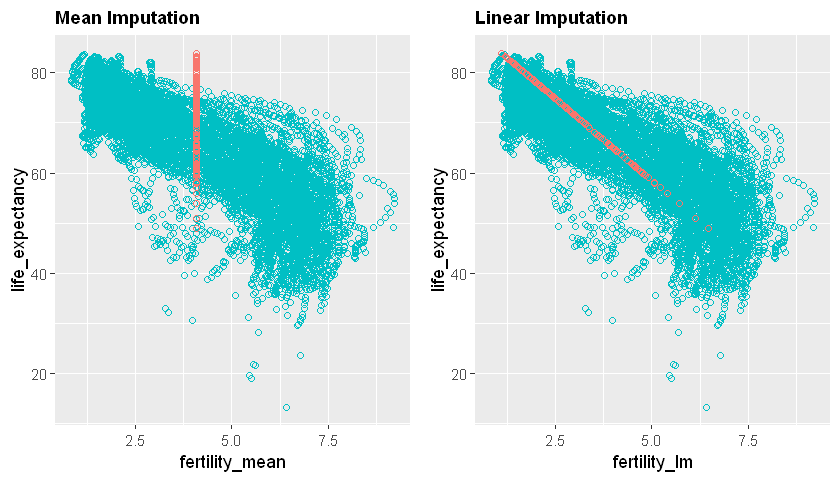

```r
gap <- gapminderall %>%
    select(fertility, life_expectancy) %>%
    bind_shadow(only_miss=TRUE) %>%
    add_label_shadow() %>%
    mutate(fertility_mean=fertility, fertility_lm=fertility) %>%
    impute_proxy(fertility_mean ~ mean(fertility_mean, na.rm=TRUE)) %>%
    impute_lm(fertility_lm ~ life_expectancy)

options(repr.plot.width=7, repr.plot.height=4)
mean <- gap %>%
    ggplot(aes(x=fertility_mean, y=life_expectancy, colour=any_missing)) +
    geom_point(shape=21) +
    ggtitle('Mean Imputation') +
    theme(legend.position='none', plot.title=element_text(size=11, face='bold'))
lm <- gap %>%
    ggplot(aes(x=fertility_lm, y=life_expectancy, colour=any_missing)) +
    geom_point(shape=21) +
    ggtitle('Linear Imputation') +
    theme(legend.position='none', plot.title=element_text(size=11, face='bold'))
grid.arrange(mean, lm, ncol=2)
```

### Question 2

```r
casMotor <- read_csv('data/Case Study 2 - CAS Motor/freMTPL2freq.csv', col_types=cols())
glimpse(casMotor)
casMotor <- casMotor %>%
    mutate(logDen = log(Density)) %>%
    mutate(logDenGroup = ifelse(floor(logDen+1) <= 10, floor(logDen+1), 10))
head(casMotor, 3)
```

```
Observations: 678,013
Variables: 12
$ IDpol      <dbl> 1, 3, 5, 10, 11, 13, 15, 17, 18, 21, 25, 27, 30, 32, 35,...
$ ClaimNb    <dbl> 1, 1, 1, 1, 1, 1, 1, 1, 1, 1, 1, 1, 1, 1, 1, 1, 1, 1, 1,...
$ Exposure   <dbl> 0.10, 0.77, 0.75, 0.09, 0.84, 0.52, 0.45, 0.27, 0.71, 0....
$ Area       <chr> "D", "D", "B", "B", "B", "E", "E", "C", "C", "B", "B", "...
$ VehPower   <dbl> 5, 5, 6, 7, 7, 6, 6, 7, 7, 7, 7, 7, 4, 4, 4, 9, 6, 6, 6,...
$ VehAge     <dbl> 0, 0, 2, 0, 0, 2, 2, 0, 0, 0, 0, 0, 1, 0, 9, 0, 2, 2, 2,...
$ DrivAge    <dbl> 55, 55, 52, 46, 46, 38, 38, 33, 33, 41, 41, 56, 27, 27, ...
$ BonusMalus <dbl> 50, 50, 50, 50, 50, 50, 50, 68, 68, 50, 50, 50, 90, 90, ...
$ VehBrand   <chr> "B12", "B12", "B12", "B12", "B12", "B12", "B12", "B12", ...
$ VehGas     <chr> "Regular", "Regular", "Diesel", "Diesel", "Diesel", "Reg...
$ Density    <dbl> 1217, 1217, 54, 76, 76, 3003, 3003, 137, 137, 60, 60, 17...
$ Region     <chr> "R82", "R82", "R22", "R72", "R72", "R31", "R31", "R91", ...
```

| IDpol | ClaimNb | Exposure | Area | VehPower | VehAge | DrivAge | BonusMalus | VehBrand | VehGas | Density | Region | logDen | logDenGroup |
| --- | --- | --- | --- | --- | --- | --- | --- | --- | --- | --- | --- | --- | --- |
| 1 | 1 | 0.10 | D | 5 | 0 | 55 | 50 | B12 | Regular | 1217 | R82 | 7.104144 | 8 |
| 3 | 1 | 0.77 | D | 5 | 0 | 55 | 50 | B12 | Regular | 1217 | R82 | 7.104144 | 8 |
| 5 | 1 | 0.75 | B | 6 | 2 | 52 | 50 | B12 | Diesel | 54 | R22 | 3.988984 | 4 |

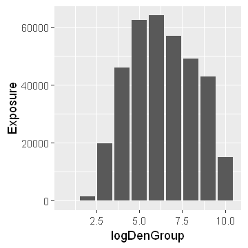

```r
options(repr.plot.width=3, repr.plot.height=3)
casMotor %>%
    ggplot(aes(logDenGroup, Exposure)) +
    geom_col()
```

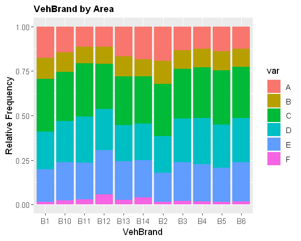

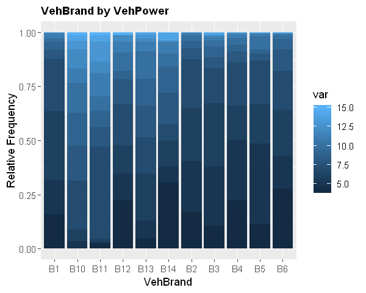

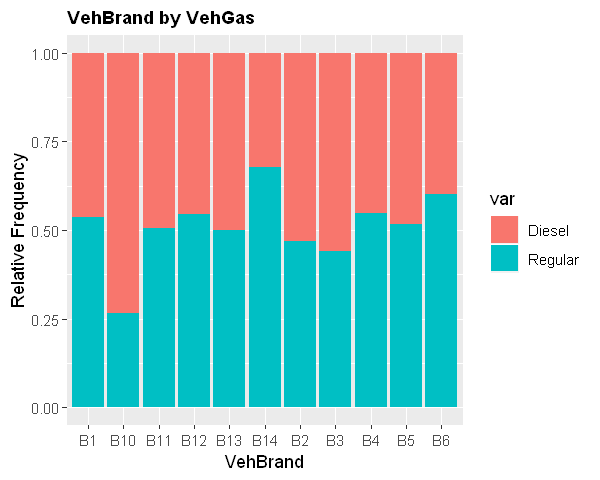

```r
options(repr.plot.width=5, repr.plot.height=4)

temp <- function(data, col) {
    data %>%
        group_by(brand=VehBrand, var=data[[col]]) %>%
        summarise(count=table(var)) %>%
        mutate(pcByCol=count/sum(count)) %>%
        ggplot(aes(x=brand, y=pcByCol, fill=var)) +
        geom_col() +
        xlab('VehBrand') +
        ylab('Relative Frequency') +
        ggtitle(paste('VehBrand by', col)) +
        theme(plot.title=element_text(size=11, face='bold'))
}

temp(casMotor, 'Area')
temp(casMotor, 'VehPower')
temp(casMotor, 'VehGas')
```

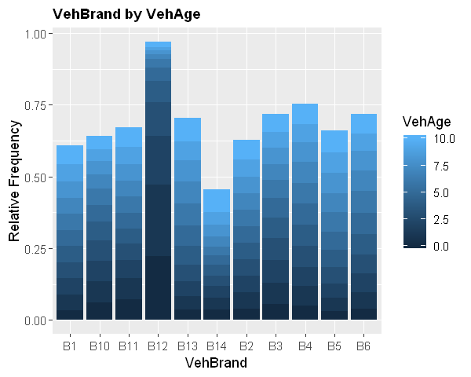

```r
vehBrand_byAge <- casMotor %>%
    group_by(VehBrand, VehAge) %>%
    summarise(count=table(VehAge)) %>%
    mutate(pcByVehAge=count/sum(count))
# head(vehBrand_byAge)
vehBrand_byAge %>%
    filter(VehAge <= 10) %>%
    ggplot(aes(x=VehBrand, y=pcByVehAge, fill=VehAge)) +
    geom_col() +
    xlab('VehBrand') +
    ylab('Relative Frequency') +
    ggtitle('VehBrand by VehAge') +
    theme(plot.title=element_text(size=11, face='bold'))
```

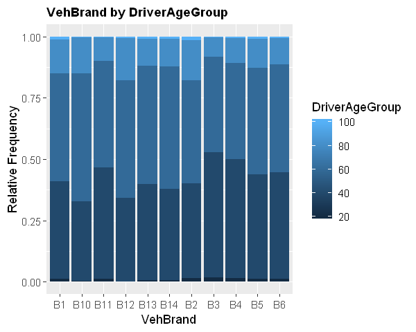

```r
casMotor$DriverAgeGroup <- ceiling(casMotor$DrivAge/20)*20
vehBrand_byDriverAgeGroup <- casMotor %>%
    group_by(VehBrand, DriverAgeGroup) %>%
    summarise(count=table(DriverAgeGroup)) %>%
    mutate(pcByDriverAgeGroup=count/sum(count))
# head(vehBrand_byDriverAgeGroup)
vehBrand_byDriverAgeGroup %>%
    ggplot(aes(x=VehBrand, y=pcByDriverAgeGroup, fill=DriverAgeGroup)) +
    geom_col() +
    xlab('VehBrand') +
    ylab('Relative Frequency') +
    ggtitle('VehBrand by DriverAgeGroup') +
    theme(plot.title=element_text(size=11, face='bold'))
```

### Question 3

```r
bank <- read_csv('data/Case Study 3 - Big Bank/creditcardcut.csv', col_types=cols())

set.seed(123)
idx <- sort(sample(nrow(bank), nrow(bank)*0.6))
bank_train <- bank[idx,]
bank_test <- bank[-idx,]
```

## Resources

- [Rounding numbers in R](https://www.dummies.com/programming/r/how-to-round-off-numbers-in-r/)